# Notebook

### Web Information Retrieval and Data Mining - Assignment 3

```
Student: Ussin, Erik (1034012)
```

#### Answer 1.1, Baseline (4p)

- Dense network, at least 3 layers, shaped like a pyramid
  - Last layer: 10 nodes, sigmoid.
  - Loss: categorical cross-entropy. Metric: accuracy
- No preprocessing, regularization. Get at least 70% accuracy.
- Explain design decisions. Discuss performance.
  - Does it overfit (large/growing gap between loss and val_loss)?

```
3 dense layers are used of 75%, 70% and 65% of nodes compared to its previous layer. This provided the best balance between training time and validation accuracy. The output layer uses Softmax since we have 10 output classes. Adagrad was used as optimizer for its learning rate decay to improve accur…

Max val score: 78.62%
```

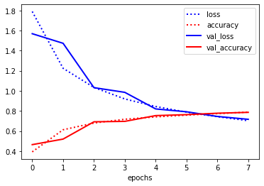

```
Model: "sequential_30"
_________________________________________________________________
Layer (type)                 Output Shape              Param #
=================================================================
reshape_6 (Reshape)          (None, 3072)              0
_________________________________________________________________
dense_68 (Dense)             (None, 2304)              7080192
_________________________________________________________________
dense_69 (Dense)             (None, 1612)              3715660
_________________________________________________________________
dense_70 (Dense)             (None, 1048)              1690424
_________________________________________________________________
dense_71 (Dense)             (None, 10)                10490
=================================================================
Total params: 12,496,766
Trainable params: 12,496,766
Non-trainable params: 0
_________________________________________________________________
None
def build_model_1_1():
    model = models.Sequential()
    nodes = 32 * 32 * 3
    model.add(layers.Reshape((nodes,), input_shape=(32,32,3)))
    nodes = nodes * (0.75)
    model.add(layers.Dense(nodes, activation='relu'))
    nodes = nodes * (0.70)
    model.add(layers.Dense(nodes, activation='relu'))
    nodes = nodes * (0.65)
    model.add(layers.Dense(nodes, activation='relu'))
    nodes = 10
    model.add(layers.Dense(nodes, activation='softmax'))

    model.compile(optimizer=optimizers.Adagrad(lr=0.005),
                  loss='categorical_crossentropy',
                  metrics=['accuracy'])

    return model
```

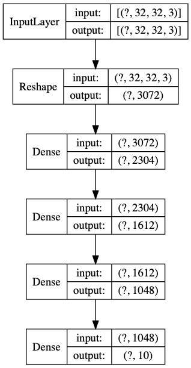

#### Answer 1.2, Preprocess (2p)

- Convert images to greyscale, other preprocessing optional.
  - Input shape should be (32,32,1)
- Explain design decisions. Is it better? Why (not)?
  - Color information is likely not so useful for classification. Greyscale makes the network smaller, less parameters to learn, less likely to overfit.

[output not shown]

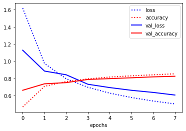

```
Model: "sequential_33"
_________________________________________________________________
Layer (type)                 Output Shape              Param #
=================================================================
reshape_9 (Reshape)          (None, 1024)              0
_________________________________________________________________
dense_80 (Dense)             (None, 768)               787200
_________________________________________________________________
dense_81 (Dense)             (None, 537)               412953
_________________________________________________________________
dense_82 (Dense)             (None, 349)               187762
_________________________________________________________________
dense_83 (Dense)             (None, 10)                3500
=================================================================
Total params: 1,391,415
Trainable params: 1,391,415
Non-trainable params: 0
_________________________________________________________________
None
def build_model_1_2():
    model = models.Sequential()
    nodes = 32 * 32 * 1
    model.add(layers.Reshape((nodes,), input_shape=(32,32,1)))
    nodes = nodes * (0.75)
    model.add(layers.Dense(nodes, activation='relu'))
    nodes = nodes * (0.70)
    model.add(layers.Dense(nodes, activation='relu'))
    nodes = nodes * (0.65)
    model.add(layers.Dense(nodes, activation='relu'))
    nodes = 10
    model.add(layers.Dense(nodes, activation='softmax'))

    model.compile(optimizer=optimizers.Adagrad(lr=0.005),
                  loss='categorical_crossentropy',
                  metrics=['accuracy'])

    return model
```

#### Answer 1.3, Tune (4p)

- Regularize the model. What works best?
  - Should consider batch normalization, dropout, l1/l2 regularization (or Nesterov)
- Tune other hyperparameters (e.g. learning rate, batch size,...) as you see fit.
  - At least consider tuning learning rate, ideally also momentum, decay, other optimizers
- Explain your findings and final design decisions. Discuss the results.
  - Should be better, at least it shouldn't overfit

[output not shown]

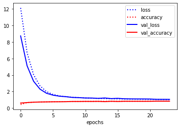

```
def build_model_1_3():
    model = models.Sequential()
    nodes = 32 * 32 * 1
    model.add(layers.Reshape((nodes,), input_shape=(32,32,1)))
    nodes = nodes * (0.75)
    model.add(layers.Dense(
        nodes,
        kernel_regularizer=regularizers.l1_l2(l1=0.0001, l2=0.005),
        bias_regularizer=regularizers.l2(0.01),
        activation='relu'
    ))
    nodes = nodes * (0.70)
    model.add(layers.Dense(
        nodes,
        kernel_regularizer=regularizers.l1_l2(l1=0.0001, l2=0.005),
        bias_regularizer=regularizers.l2(0.01),
        activation='relu'
    ))
    nodes = nodes * (0.65)
    model.add(layers.Dense(
        nodes,
        kernel_regularizer=regularizers.l1_l2(l1=0.0001, l2=0.005),
        bias_regularizer=regularizers.l2(0.01),
        activation='relu'
    ))
    nodes = 10
    model.add(layers.Dense(nodes, activation='softmax'))

    model.compile(optimizer=optimizers.Adagrad(lr=0.01),
                  loss='categorical_crossentropy',
                  metrics=['accuracy'])

    return model
```

#### Answer 2.1, ConvNet (7p)

- Build a sequential ConvNet, get at least 90% accuracy.
  - Conv2D layers, input shape (32,32,1)
  - Consider using blocks of Conv2D layers with maxpooling in between
  - Use zero-padding in Conv2D layers because the images are small
  - At least one dense hidden layer and dense output layer (sigmoid)
  - Consider adding batch normalization, dropout
  - Consider small dropout rates in beginning, larger dropout rates later in network
  - Consider other optimizers and tuning learning rate, momentum,...
- Explain what you did and why (800 chars). Is it working well?
  - Should be quite elaborate and sensible

```
The same pre-procesing from the previous model was used as this allowed a significant reduction on the number of parameters in the network, no additional steps were required. The model contains 4 convolutional layers. The 1st 2 convolutional layers are followed by a MaxPooling layer in order to redu…

Max val score: 94.82%
```

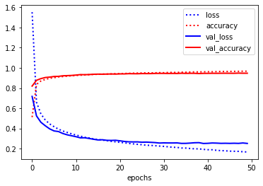

```
Model: "sequential_20"
_________________________________________________________________
Layer (type)                 Output Shape              Param #
=================================================================
conv2d_54 (Conv2D)           (None, 29, 29, 32)        544
_________________________________________________________________
conv2d_55 (Conv2D)           (None, 26, 26, 32)        16416
_________________________________________________________________
max_pooling2d_15 (MaxPooling (None, 13, 13, 32)        0
_________________________________________________________________
dropout_39 (Dropout)         (None, 13, 13, 32)        0
_________________________________________________________________
conv2d_56 (Conv2D)           (None, 10, 10, 64)        32832
_________________________________________________________________
conv2d_57 (Conv2D)           (None, 7, 7, 64)          65600
_________________________________________________________________
flatten_15 (Flatten)         (None, 3136)              0
_________________________________________________________________
dropout_40 (Dropout)         (None, 3136)              0
_________________________________________________________________
dense_53 (Dense)             (None, 2048)              6424576
_________________________________________________________________
dropout_41 (Dropout)         (None, 2048)              0
_________________________________________________________________
dense_54 (Dense)             (None, 512)               1049088
_________________________________________________________________
dense_55 (Dense)             (None, 10)                5130
=================================================================
Total params: 7,594,186
Trainable params: 7,594,186
Non-trainable params: 0
_________________________________________________________________
None
def build_model_2_1():
    model = models.Sequential()
    model.add(layers.Conv2D(
        32, (4, 4),
        kernel_regularizer=regularizers.l2(0.001),
        bias_regularizer=regularizers.l2(0.01),
        activation='relu',
```

[output cut: 19 more lines]

```
        bias_regularizer=regularizers.l2(0.01),
        activation='relu'
    ))
    model.add(layers.Flatten())
    model.add(layers.Dropout(0.5))
    model.add(layers.Dense(2048, activation='relu'))
    model.add(layers.Dropout(0.25))
    model.add(layers.Dense(512, activation='relu'))
    model.add(layers.Dense(10, activation='softmax'))

    model.compile(optimizer=optimizers.Adagrad(lr=0.01),
                  loss='categorical_crossentropy',
                  metrics=['accuracy'])

    return model
```

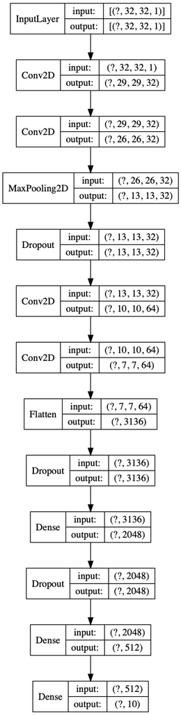

#### Answer 2.2, Data Augmentation (3p)

- Augment the preprocessed training data.
  - Use small variations (small shifts up-down, left-right) of flips becasue the images are small
  - Large shifts and rotations distort the image too much
- Explain what you did and why. Discuss the performance of the model.

```
Rotation, shift and flipping did not appear to yeld better results. This makes sense because we are trying to identify the number at the center of the image. Zooming and shearing however improved the results in terms of overfitting. This yelded a result of 94.8% validation accuracy with roughly the …

Max val score: 94.78%
```

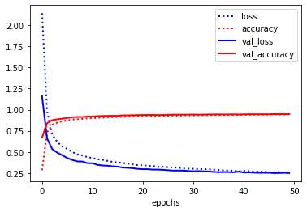

```
generator = ImageDataGenerator(
      rotation_range=0,
      width_shift_range=0.0,
      height_shift_range=0.0,
      shear_range=0.2,
      zoom_range=0.2,
      horizontal_flip=False,
      fill_mode='nearest')
```

#### Answer 3.1, Misclassifications (2p)

[output not shown]

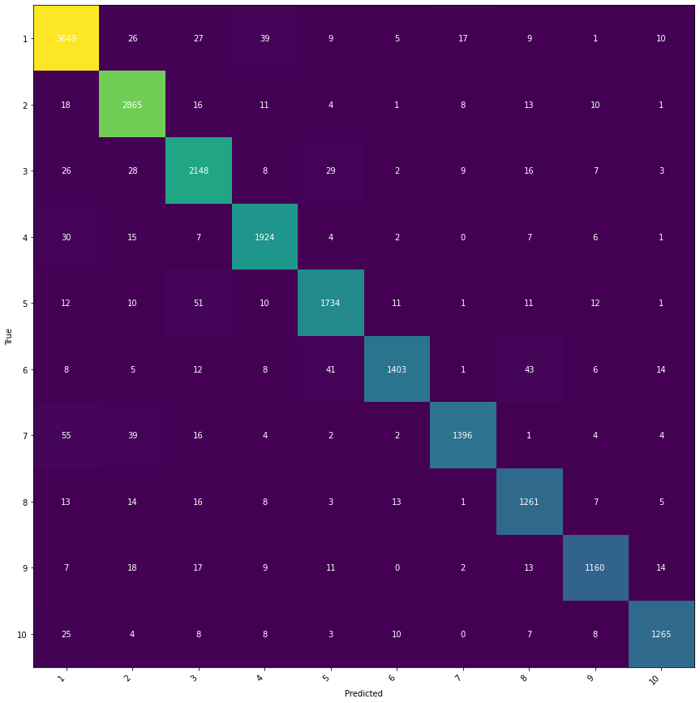

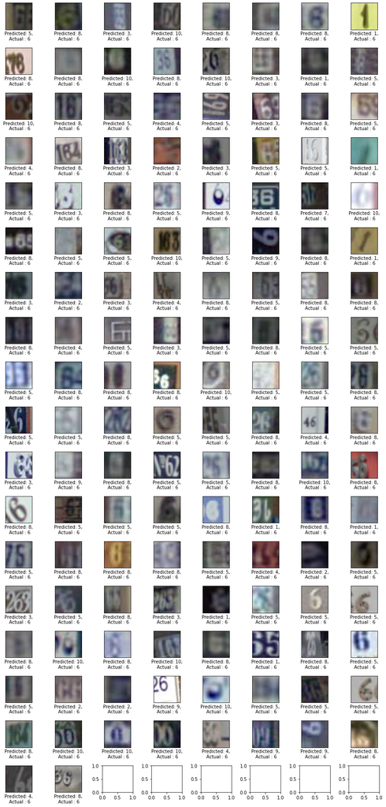

#### Answer 3.2, Activations (4p)

- Retrieve and visualize the activations for one example
- For every filter for different convolutional layers (at different depths in the network).
- Give an explanation. Is your model indeed learning something useful?
  - Should detect edges etc in first layers, higher-order object (e.g. interesting regions) in deeper layers.

```
The 1st convolutional layer isolates the numbers in the image from the background and hence can be considered an edge detector. The 2nd seems to to look for lines whilst the 3rd looks for specific shapers and the 4rth is not very clear but it seems to be patters. The 3rd and 4rth layers are hard to …
```

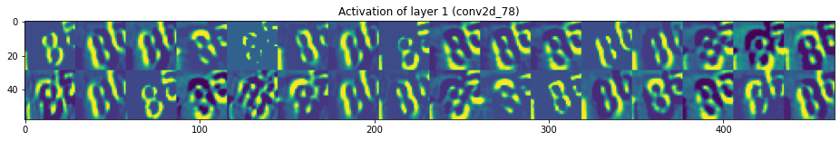

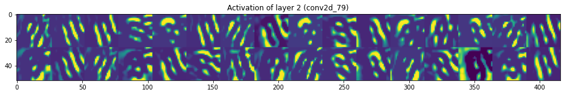

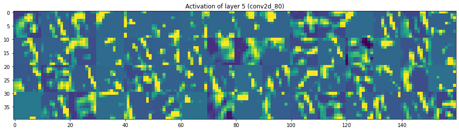

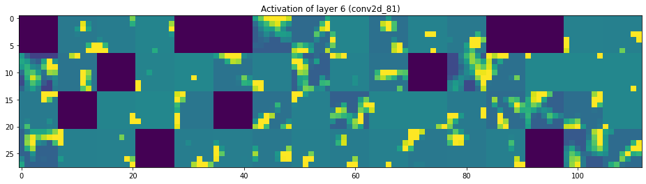

#### Answer 3.3, Class activation map (4p)

- Show a class activation map for your last convolutional layer
- Superimpose the activation map over the image, or plot side by side
  - Should make sense, detect interesting regions to classify the number

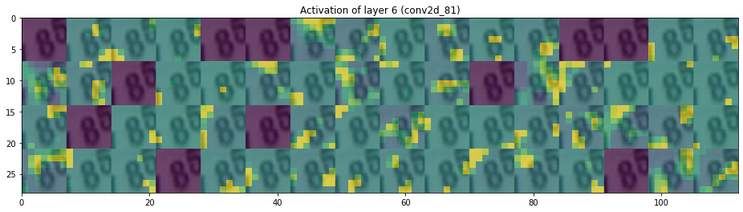

```
def plot_activation_map(model, img):
    activations = model.predict(rgb2gray([img]))
    plot_layer_activation(5, activations, True, img)
```

#### Answer 4.1, Fast feature extraction (5p)

- Import the VGG16 model, pretrained on ImageNet
- Freeze convolutional base, adds a dense layer
- Consider unfreezing the last few convolutional layers and evaluate whether that works better
  - Check if they do. It is very likely to help.
- Discuss the observed performance
  - Should get around 80% accuracy

```
Unfreezing the last block convolutional layers of the imagenet network substantially improves the validation accuracy of the network as it achieved ~81.5% instead of ~55% with it frozen. It is interesting to note however, that the network starts to overfit very quickly as within 5 epoch the accuracy…

Max val score: 81.47%
```

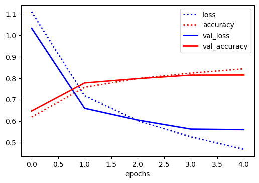

```
Model: "sequential_19"
_________________________________________________________________
Layer (type)                 Output Shape              Param #
=================================================================
vgg16 (Model)                (None, 1, 1, 512)         14714688
_________________________________________________________________
flatten_13 (Flatten)         (None, 512)               0
_________________________________________________________________
dense_40 (Dense)             (None, 2048)              1050624
_________________________________________________________________
dense_41 (Dense)             (None, 10)                20490
=================================================================
Total params: 15,785,802
Trainable params: 8,150,538
Non-trainable params: 7,635,264
_________________________________________________________________
None
def build_model_4_1():
    vgg16_base = VGG16(weights='imagenet', include_top=False, input_shape=(32, 32, 3))
    # Select which layers to train and which not to train
    for layer in vgg16_base.layers:
        if layer.name == 'block5_conv1' or layer.name == 'block5_conv2' or layer.name == 'block5_conv3':
            layer.trainable = True
        else:
            layer.trainable = False
    # Extend vgg16_base model
    model = models.Sequential()
    model.add(vgg16_base)
    model.add(layers.Flatten())
    model.add(layers.Dense(2048, activation='relu'))
    model.add(layers.Dense(10, activation='softmax'))
    # Compile model
    model.compile(optimizer=optimizers.Adagrad(lr=0.01),
                  loss='categorical_crossentropy',
                  metrics=['accuracy'])
    # Return model
    return model
```

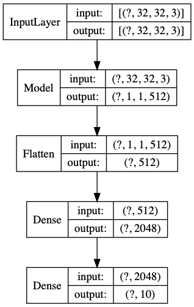

#### Answer 4.2, Embeddings (5p)

- Generate embeddings with the trained convolutional part of model_4_1 (without the dense layer)
- Embed the training and test data and store them to disk
- Build and evaluate a pipeline on the embedded data
  - Check if pipeline makes sense (e.g. use models that can handle many dimensions)
- Describe what you did and what you observed (max 800 chars).
  - Consider different models, preprocessing, tuning, etc.
  - Check performance (see original Submission.html) when in doubt. We did not run all the evaluations because it takes too long, and the output is ill-defined.

```
SVC and RandomForest were tested both of which input data ran through a StandardScaler. RandomForest outperformed SVC by ~1%. To reduce training time a split of the train data was used for training and a grid search on the relevant parameters of RandomForest and SVC was used to maximize the accuracy…

Pipeline(steps=[('pre-processing',
                 Pipeline(steps=[('scaler', StandardScaler())])),
                ('clf', RandomForestClassifier(n_jobs=-1, random_state=1))])
def store_embeddings():
   # Stores all necessary embeddings to file
    model_4_1 = load_model_from_file(base_dir, "model_4_1", extension='.h5')
    # Model with VGG only and last convolutional layer as output
    model = models.Model(inputs=model_4_1.layers[0].input, outputs=model_4_1.layers[0].layers[-1].output)

    print("Processing train data")
    res = model.predict(X_train)
    print("Storing train data")
    store_embedding(np.squeeze(res), "train")
    print("Processing test data")
    res = model.predict(X_test)
    print("Storing test data")
    store_embedding(np.squeeze(res), "test")

def evaluation_4_2(X_train, y_train, X_test, y_test):
  # Runs 'evaluate_pipeline' with embedded versions of the input data
  # and returns the accuracy.
    pipe = generate_pipeline()
    # Load embeddings or create them if they don't exist
    try:
        X_train_embeddings = load_embedding('train')
        X_test_embeddings = load_embedding('test')
    except FileNotFoundError:
        store_embeddings()
        X_train_embeddings = load_embedding('train')
        X_test_embeddings = load_embedding('test')
    # Reduce training sample size in order to speed up training
    X_train_split, X_test_split, y_train_split, y_test_split = train_test_split(
        X_train_embeddings, np.argmax(y_train, axis=1), train_size=0.25, test_size=0.10
    )
    # Perform Evaluation
    acc = evaluate_pipeline(pipe, X_train_split, y_train_split,  X_test_embeddings, np.argmax(y_test, axis=1))
    print("Accuracy: {:.2f}".format(acc))
    # Return accuracy on test set
    return acc
```

```
Running time: 21.36 seconds
Last modified: May 26, 2020
scikit-learn version: 0.23.1
```